# Ryzyko rynkowe

Wiktoria Szczypka

7 kwietnia 2019

## Wstęp

W projekcie moim celem będzie zbadanie, która technika wyznaczania Value at Risk (VaR) jest najlepsza. Aby zrealizować mój cel wybrałam 3 kursy walutowe z lat 2012-2018 - walutę kanadyjską, czeską oraz ukraińską. Będę porównywać 3 metody wyznaczania VaR:

- historyczną
- bootstrap
- Monte Carlo

Oprócz VaR będę wyznaczać również Expected Shortfall (ES), pozwoli to zobaczyć ile średnio będzie wynosić strata jeżeli VaR zostanie przekroczony. Pozwoli to lepiej zobrazować sytuację.

VaR będę wyznaczać stosując ruchome 500-elementowe okno estymacji, otrzymam więc 1263 wartości VaR oraz ES. Obie miary będę wyznaczać na poziomie 99%.

Następnie wykonam testy wsteczne dla każdej metody i na ich podstawię postaram się przedstawić, którą z wyżej wymienionych metod można uznać za najlepszą.

### Przedstawienie danych

Poniżej przedstawię statystyki opisowe wybranych przeze mnie walut.

```
##      X1CAD           X1UAH            X1CZK
##  Min.   :2.608   Min.   :0.1094   Min.   :0.1451
##  1st Qu.:2.846   1st Qu.:0.1452   1st Qu.:0.1553
##  Median :2.952   Median :0.1709   Median :0.1620
##  Mean   :2.973   Mean   :0.2377   Mean   :0.1604
##  3rd Qu.:3.092   3rd Qu.:0.3800   3rd Qu.:0.1651
##  Max.   :3.445   Max.   :0.4420   Max.   :0.1751
```

Na pierwszy rzut oka można zauważyć, że największa różnica w kursie jest w walucie kanadyjskiej - około 0.8. Jednak po dokładniejszym zapoznaniu się widać, że w walucie ukraińskiej różnica w kursie między minimum a maximum jest czterokrotna. Jest to zapewne spowodowane tym, że Ukraina jest krajem niestabilnym gospodarczo. Kurs waluty czeskiej wydaję się być stabilny.

Poniżej przedstawię wykresy kursów, aby widać było jak się zmieniały w poszczególnych latach.

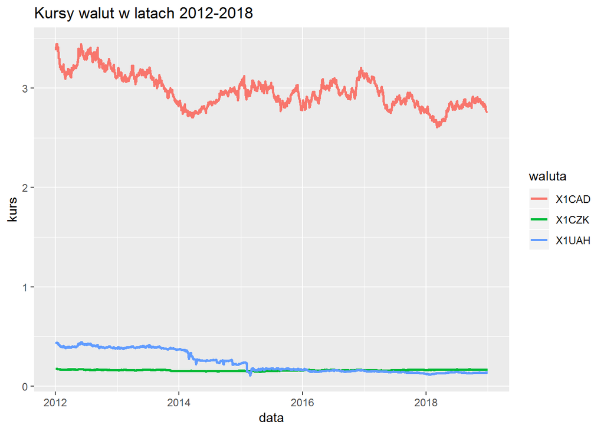

Widać, że waluta ukraińska miała duży spadek, waluta czeska jest bardzo stabilna, a kanadyjska ma rożne wahania - czasem spadek, czasem wzrost.

Za pomocą poniższej funkcji obliczę teraz logarytmiczną stopę zwrotu walut, a następnie przedstawię je na wykresie. Stopa zwrotu będzie w procentach z przeciwnym znakiem, aby straty występowały w prawym ogonie rozkładu.

```r
return_rate <- function(vec){
  rate <- NA

  for (i in 2:length(vec)){
    rate[i] <-log(vec[i]/vec[i-1])
  }
  #prawy ogon - straty
  -rate*100
}
```

Przedstawię poniżej na wykresach stopy zwrotu poszczególnych walut.

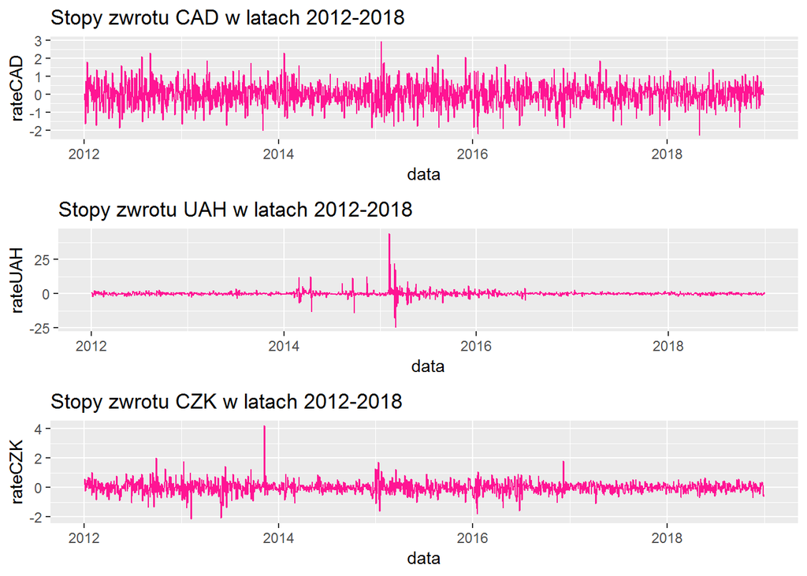

Widać od razu, że w walucie ukraińskiej stopy zwrotu dochodzą aż do 50%, może to świadczyć o dużym ryzyku jeżeli inwestuje się w tą walutę. Pozostałe stopy są stabilniejsze.

## Metody obliczania VaR

W tej części projektu zajmę się przedstawieniem 3 technik wyznaczania VaR i uzyskanych wyników.

### Metoda historyczna

Metoda ta opiera się na bezpośrednim wykorzystaniu danych historycznych. Na podstawie tych danych w każdym okienku 500 obserwacji tworzy się rozkład empiryczny stóp zwrotu za pomocą którego jest się w stanie wyznaczyć kwantyl na danym poziomie istotności. Za pomocą kwantyla jest się w stanie już obliczyć VaR oraz ES.

Poniżej przedstawiam funkcję, która realizuje powyżej przedstawiony algorytm.

```r
hist_method <- function(vec_rate, days = 500, level=.99){

  VaR <- NA
  ES <- NA

  for (i in 2:(length(vec_rate)-500)){
    temp_vec <- vec_rate[i:(days+i-1)]
    VaR[i] <- quantile(temp_vec, level, na.rm = TRUE)
    ES[i] <- mean(temp_vec[temp_vec >= VaR[i]])
  }
  return(list(VaR=VaR, ES=ES))
}
```

Przedstawię teraz wykresy, które obrazują VaR i ES dla każdej waluty.

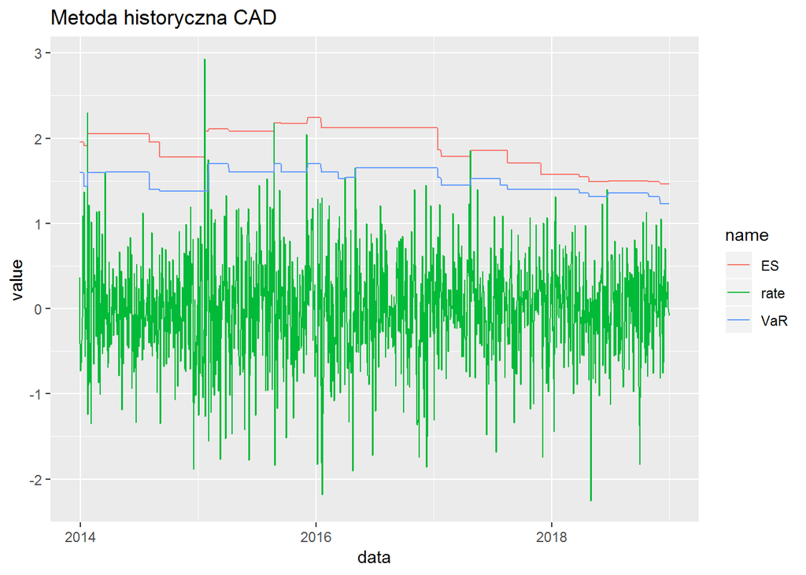

VaR przez wszystkie lata wynosi około 1,5%. Oznacza to, że na 99% inwestując w walutę nie stracimy więcej niż 1,5%. Jeżeli jednak strata przekroczy 1,5% to szacowana wartość tej straty będzie wynosić 2%.

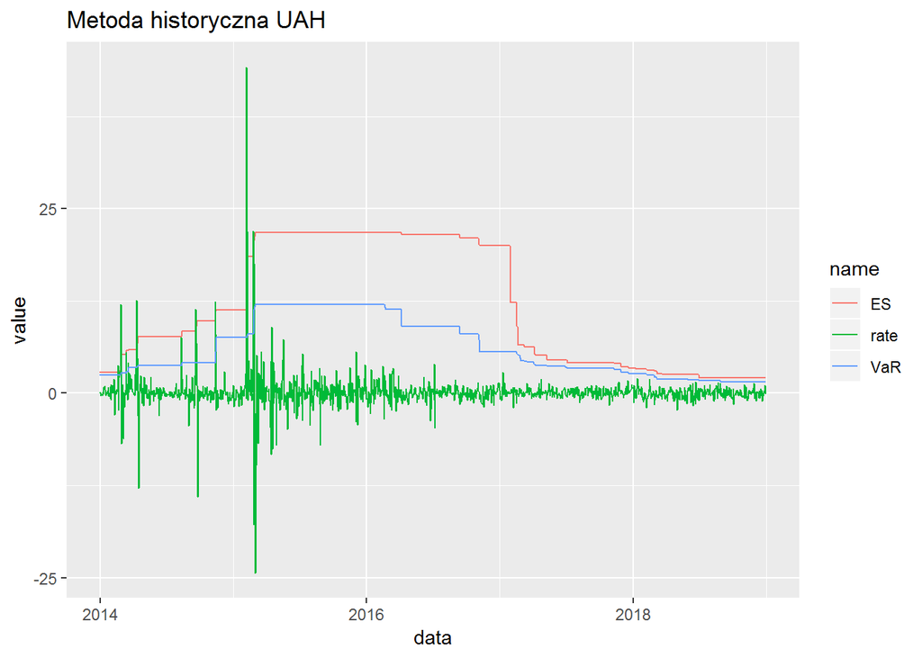

Ze względu na duży spadek kursu waluty ukraińskiej widać, ze w latach 2015-2017 VaR wynosił nawet 12,5%, a ES przyjmował wartości w pobliżu 25%.

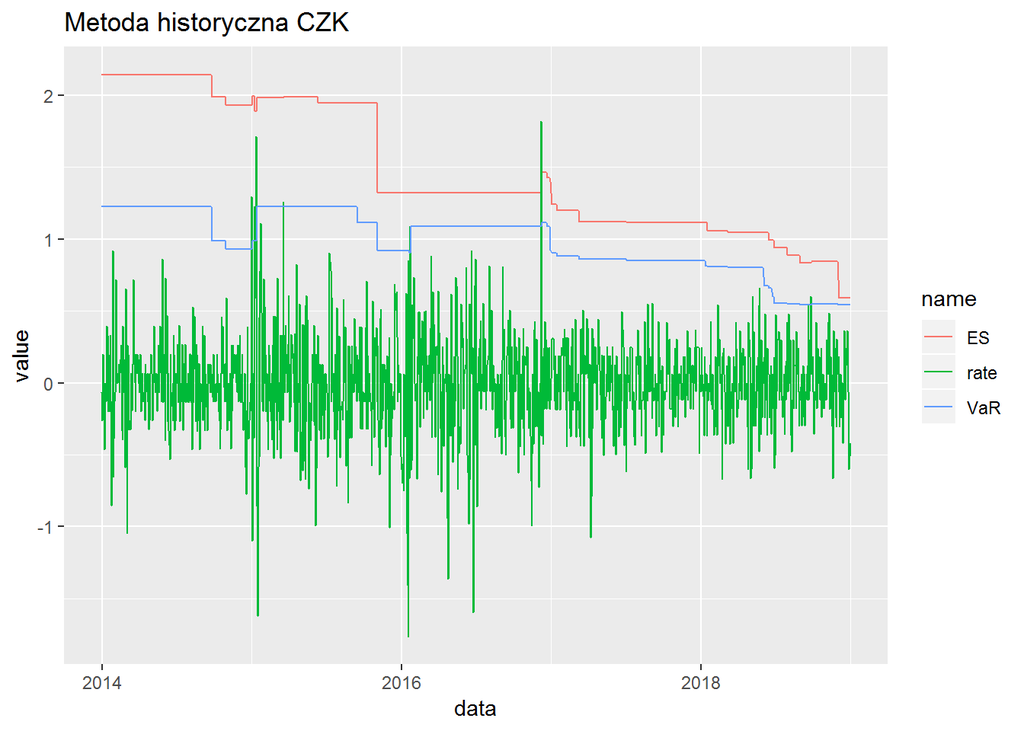

Zarówno VaR jak i ES na przestrzeni lat malało. Pod koniec 2018 roku wartość VaR wynosiła 0,5%, więc na 99% strata nie wyniesie więcej niż 0,5%. Jest to wynik potwierdzający stabilność tej waluty.

### Metoda bootstrap

Wykorzystuje się w tej metodzie metodę historyczną, lecz tworzę alternatywne historie. W każdym oknie 500 obserwacji losuję daną liczbę obserwacji ze zwracaniem, a następnie dla nich obliczam VaR metodą historyczną. Algorytm ten powtarzam N razy. Końcowa wartość VaR dla danego okna to średnia z uzyskanych wartości. Oszacowania te mogą być dokładniejsze niż w metodzie historycznej.

Poniżej przedstawiam funkcję, która realizuje powyżej przedstawiony algorytm.

```r
boot_method <- function(vec_rate, days = 500, level = .99, N = 500){

  VaR <- NA
  ES <- NA

  for (i in 2:(length(vec_rate)-500)){

    temp_vec <- vec_rate[i:(days+i-1)]
    temp_var <- NULL
    temp_es <- NULL

    for (j in 1:N){
      temp <- sample(temp_vec,700, replace = T)
      temp_var[j] <- quantile(temp, level, na.rm = TRUE)
      temp_es[j] <- mean(temp[temp >= temp_var[j]])
    }

    VaR[i] <- mean(temp_var)
    ES[i] <- mean(temp_es)
  }

  return(list(VaR=VaR, ES=ES))
}
```

Przedstawię teraz wykresy, które obrazują VaR i ES dla każdej waluty.

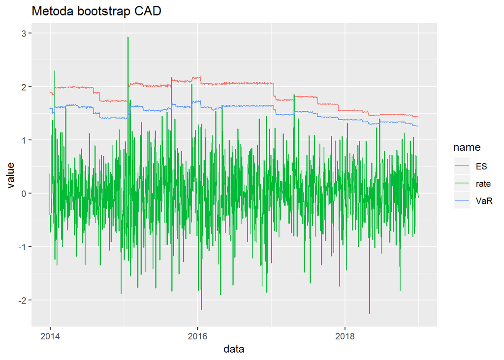

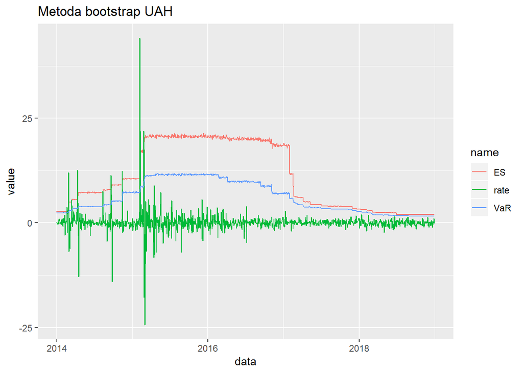

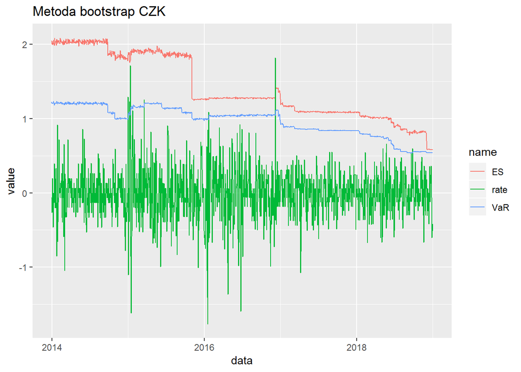

Widać, że wartości VaR i ES nie zmieniają się teraz tak skokowo jak w metodzie historycznej, lecz występują ‘drgania’. Wartości te są jednak bardzo podobne jak w poprzedniej metodzie.

### Metoda Monte Carlo

Metoda ta polega na tym, aby wybrać rozkład teoretyczny, który jak najbardziej będzie podobny do rozkładu empirycznego, które tworzy 500 obserwacji w danym okienku. Następnie z wybranego wcześniej rozkładu teoretycznego losuje ze zwracaniem daną liczbę obserwacji i na ich podstawię wyznaczam VaR tak samo jak w poprzednich metodach. Algorytm ten dla danego okna powtarzam N razy, a końcowy VaR obliczam jako ich średnią.

W swoim algorytmie będę brała pod uwagę 3 rozkłady - t-Studenta, logistyczny i normalny. Za pomocą funkcji `fitdistr` do każdego rozkładu dopasuje parametry, które najbardziej będą pasować. Uzyskam więc dla każdej waluty 3 różne ciągi wartości VaR oraz ES w zależności od rozkładu. W dalszej części projektu, za pomocą testów wstecznych, przedstawię za pomocą którego rozkładu uzyskano najlepsze wyniki.

Poniżej przedstawiam funkcję, która realizuje powyżej przedstawiony algorytm.

```r
monte_method2 <- function(vec_rate, days = 500, level = .99, N = 50){

  VaR <- data.frame(NA, NA, NA)
  colnames(VaR) <- c("t", "logis", "norm")
  ES <- data.frame(NA, NA, NA)
  colnames(ES) <- c("t", "logis", "norm")

  for (i in 2:(length(vec_rate)-500)){

    temp_vec <- vec_rate[i:(days+i-1)]
    temp_var <- data.frame(0,0,0)
    temp_es <- data.frame(0,0,0)
    colnames(temp_var) <- c("t", "logis", "norm")
    colnames(temp_es) <- c("t", "logis", "norm")

    for(j in 1:N){

      temp_t <- rt(700, fitdistr(temp_vec, "t")$estimate[3])
      temp_var[j,1] <- quantile(temp_t, level, na.rm = TRUE)
      temp_es[j,1] <- mean(temp_t[temp_t >= temp_var[j,1]])

      temp_l <- rlogis(700, fitdistr(temp_vec, "logistic")$estimate)
      temp_var[j,2] <- quantile(temp_l, level, na.rm = TRUE)
      temp_es[j,2] <- mean(temp_l[temp_l >= temp_var[j,2]])


      temp_n <- rnorm(700, fitdistr(temp_vec, "normal")$estimate)
      temp_var[j,3] <- quantile(temp_n, level, na.rm = TRUE)
      temp_es[j,3] <- mean(temp_n[temp_n >= temp_var[j,3]])
    }

    for(k in 1:3){
      VaR[i,k] <- mean(temp_var[,k])
      ES[i,k] <- mean(temp_es[,k])
    }

  }
  return(list(VaR=VaR, ES=ES))
}
```

Poniżej przedstawię otrzymane wyniki.

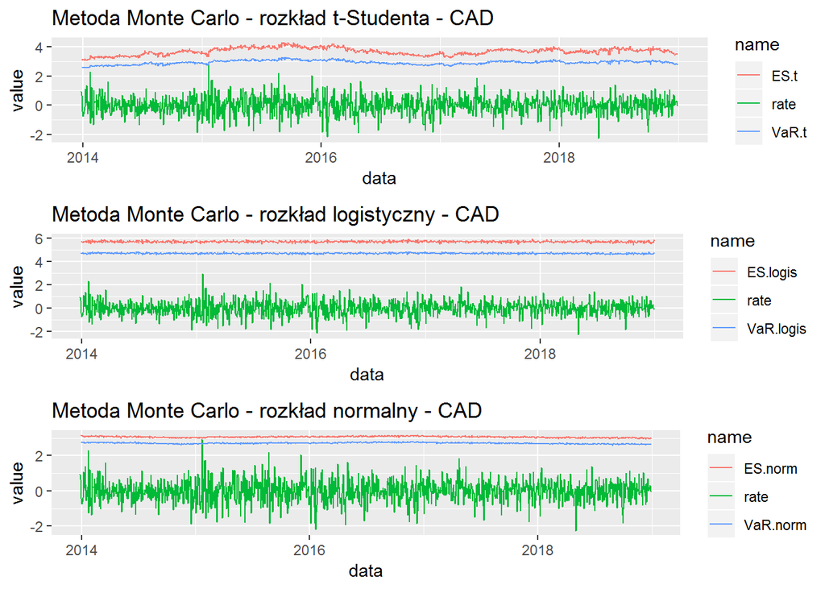

Można zauważyć, że wartość VaR i ES jest bardzo przeszacowana. Potwierdzą to testy wsteczne, ale na pierwszy rzut oka wygląda, że metoda Monte Carlo jest bardzo słaba.

Poniżej przedstawiam wartości VaR dla każdego rozkładu na jednym wykresie.

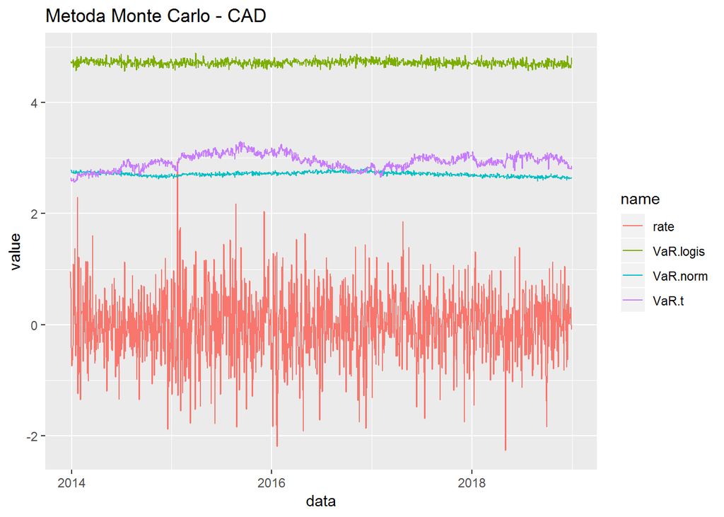

Można zauważyć, że wartości VaR oszacowane przez rozkład logistyczny są zawyżone bardziej niż przez pozostałe dwa rozkłady.

Poniżej wykresy dla waluty ukraińskiej.

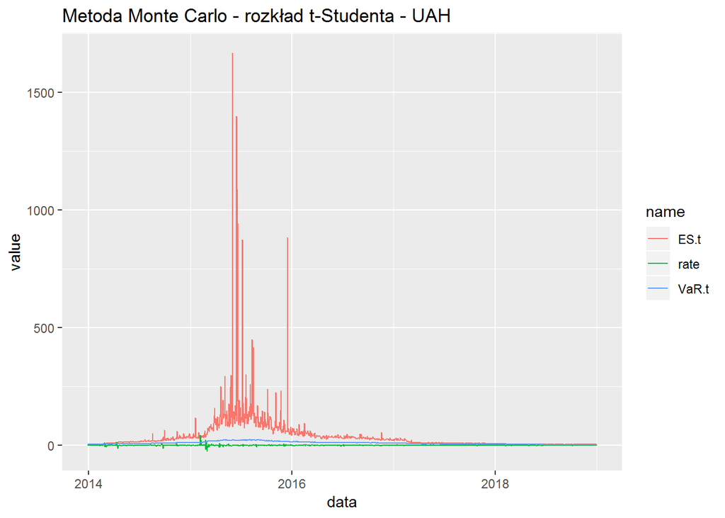

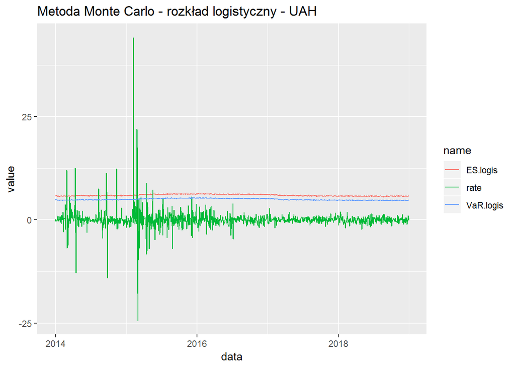

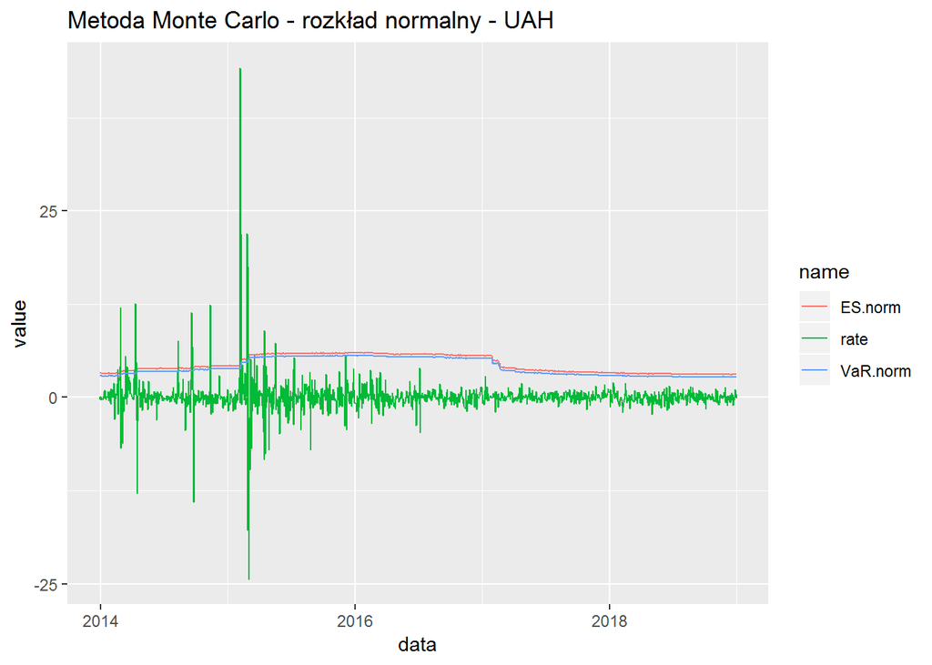

Widać, że w przypadku waluty ukraińskiej wartości nie są przeszacowane. Wyniki uzyskane za pomocą rozkładu logistycznego i normalnego można uznać za podobne. Jednak w rozkładzie t-Studenta wartość ES w pewnym punkcie była o wiele większa niż w pozostałych.

Poniżej porównanie uzyskanych wyników na jednym wykresie.

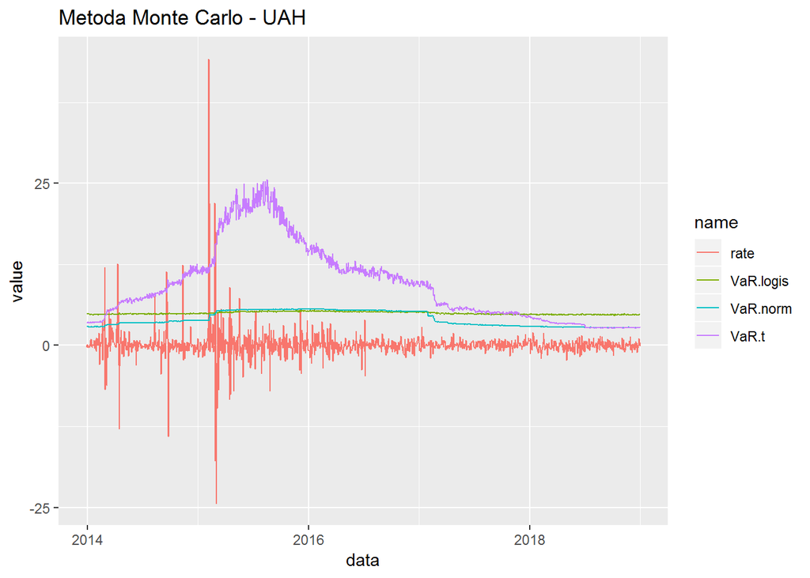

Można zauważyć, że wartość VaR obliczona za pomocą t-Studenta jest bardzo duża w porównaniu do dwóch pozostałych.

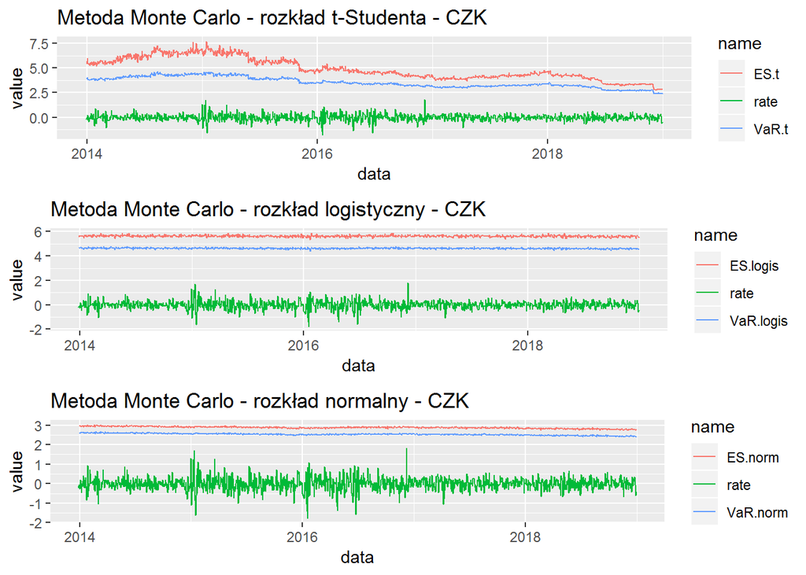

Można zauważyć, że wartości podobnie jak w przypadku waluty kanadyjskiej są bardzo przeszacowane. Występują różnice między wartościami pochodzących z różnych rozkładów. Jednak w każdym przypadku ani razu wartość stopy zwrotu nie przekracza wartości VaR.

Poniżej porównanie wyników dla trzech rozkładów.

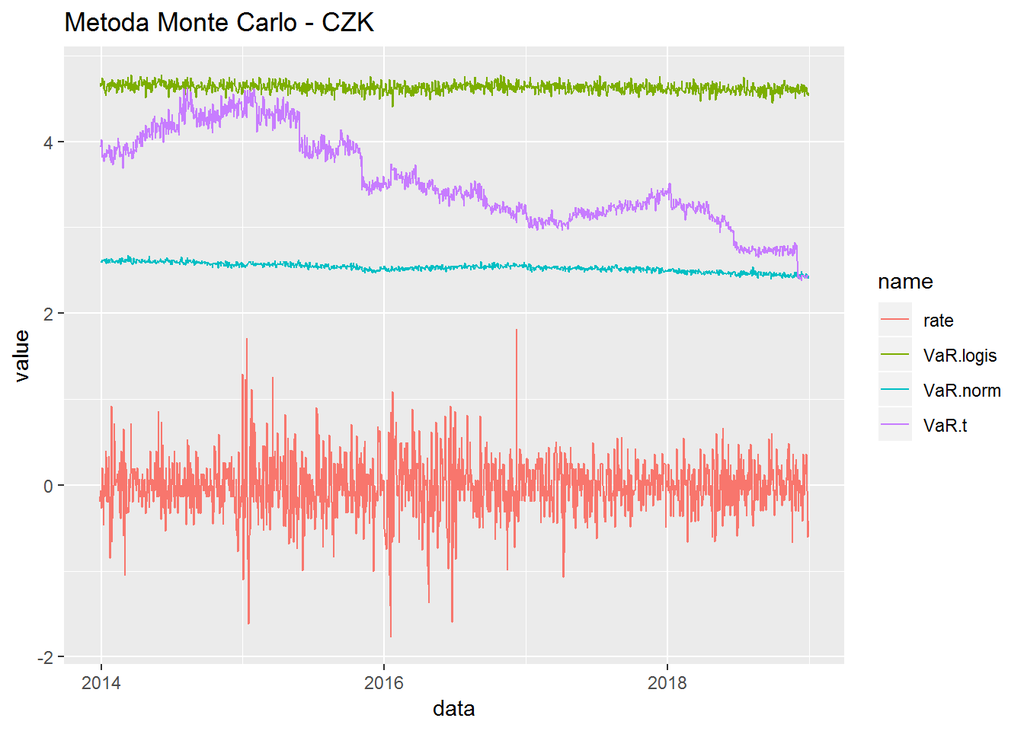

Widać różnice w wynikach jednak wygląda na to, że nie są one przydatne - są bardzo zawyżone.

### Podsumowanie metod

Poniżej wykresy przedstawiające wszystkie metody dla każdej waluty.

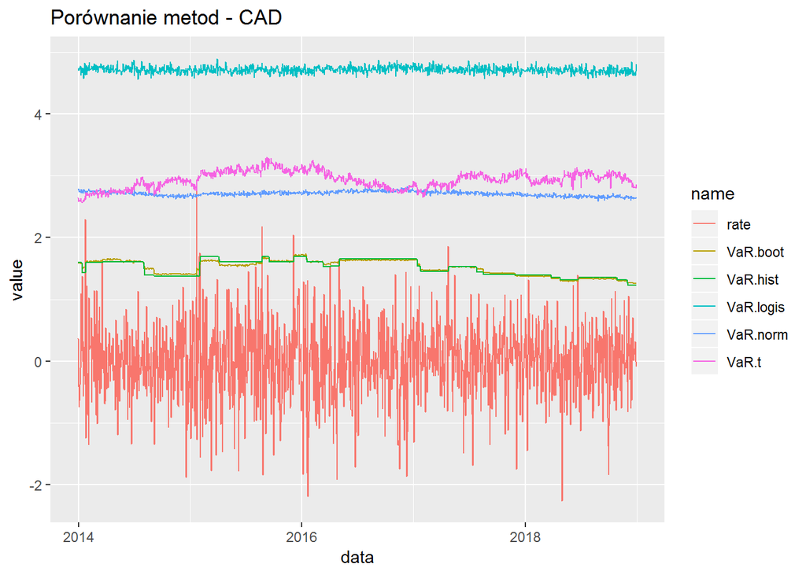

Widać, że wyniki metody historycznej i bootstrap są do siebie podobne. Można spodziewać się, że to one okażą się najlepsze, ponieważ wyniki uzyskane z metody Monte Carlo są bardzo przeszacowane.

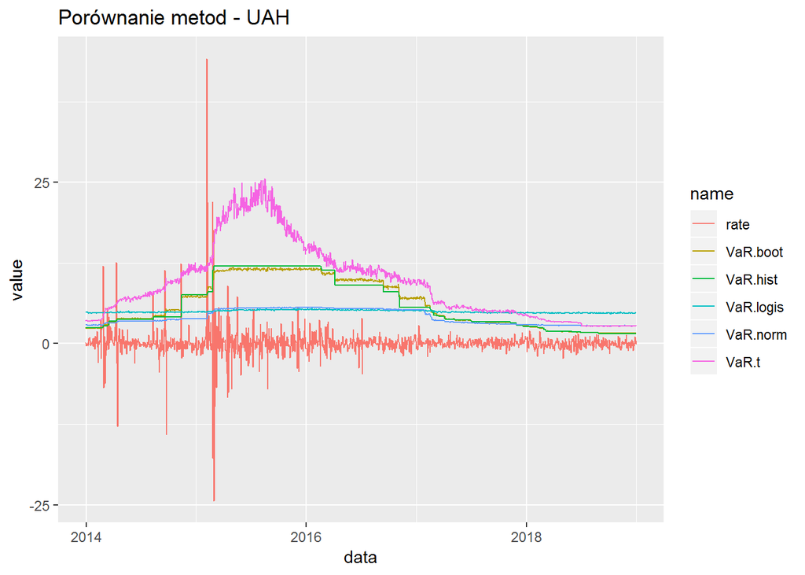

Ponownie można zauważyć, że wyniki z metody historycznej i bootstrap są podobne, tak samo jak z Monte Carlo za pomocą rozkładu logistycznego i normalnego. Ciężko określić, która z metod okaże się najlepsza. Wydaję mi się, że nie będzie to ta uzyskana z rozkładu t-Studenta, która wydaje się być przeszacowana.

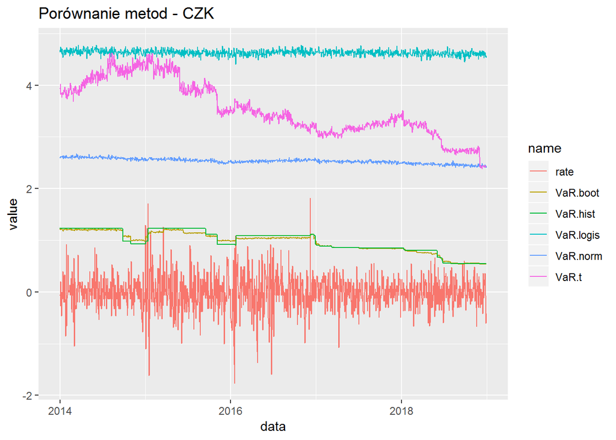

Tutaj podobnie jak w przypadku waluty kanadyjskiej: metoda Monte Carlo bardzo przeszacowana, a pozostałe wyniki są bardzo podobne.

## Testy wsteczne

W celu zbadania, która z metod dała najdokładniejsze wyniki wartości VaR wykonam testy wsteczne. Za ich pomocą postaram się odpowiedzieć, która metoda okazała się być najlepszą.

### Test wartości rzeczywistej

Pierwszym testem, który wykonam jest test wartości rzeczywistej. Porównuje on wartość VaR obliczoną na dany dzień ze stopą zwrotu. Biorąc pod uwagę, że w projekcie wyznaczam 99% VaR to im wynik (stosunek sytuacji, gdy VaR jest większy od stopy zwrotu do wszystkich obserwacji) jest bardziej zbliżony do 0.99 tym lepiej. Gdy wartość testu jest równa 1 nie jest dobrze - oznacza to, że wartości są zawyżone i niepotrzebnie będziemy magazynować kapitał.

Poniżej funkcja, która pozwala obliczyć wynik testu.

```r
test_real_value <- function(rate, VaR){

  acc = 0

  for (i in 1:length(rate)){
    if(VaR[i] > rate[i]){
      acc = acc+1
    }
  }
  return (round(acc/length(rate),3))
}
```

Teraz przedstawię tabelę z wynikami testu dla każdej metody.

```
##          CAD   UAH   CZK
## hist   0.991 0.987 0.994
## boot   0.993 0.987 0.994
## log    1.000 0.987 1.000
## normal 0.999 0.986 1.000
## t      0.999 0.992 1.000
```

Test potwierdził wcześniejsze przypuszczenia - metoda Monte Carlo w większości przypadków zawyżała wartość VaR. Dobre wyniki miała jedynie w przypadku waluty ukraińskiej. Wyniki metody historycznej i bootstrap są do siebie bardzo podobnie. Jedynie w przypadku waluty kanadyjskiej trochę lepiej wypadła metoda historyczna.

### Test Kupca

Jest to test statystyczny, który sprawdza czy VaR jest dobrze wyznaczony. Używając okien zwrotu, z których wcześniej wyliczałam VaR, badam, ile razy stopa zwrotu jest większa od wartości VaR (wyjątków). Dla okna o długości 500 i poziomu istotności 0.01 przyjmuje się, że wyestymowany VaR jest prawidłowy gdy występuje od 1 do 10 takich wyjątków. Cały algorytm powtarzam dla każdego okienka. Tym sposobem dostaję wynik od 0 do 1 - im większy tym lepiej wyznaczony został VaR.

Testu Kupca nie ma jednak sensu wykonywać dla metody historycznej i bootstrap, gdyż wynik będzie równy 1 ze względu wykorzystanie w tych metodach kwantylu bezpośrednio wyznaczonego z rozkładu empirycznego obserwacji znajdujących sie w danym okienku.

Poniżej funkcja, która przedstawia test Kupca.

```r
test_kupca <- function(rate, VaR, days = 500){

  value <- NULL
  stat <- NULL

  for (i in (1:length(var)))
  {
    temp_vec <- rate[i:(days+i-1)]

    #wyjatek 1
    excep <- ifelse(temp_vec > VaR[i], 1 , 0)
    stat[i] <- sum(excep)

    #przedzial odpowiedni - 1-10
    if (stat[i] <= 10 && stat[i] >= 1){
      value[i] <- 1
    }else {
      value[i] <- 0}
  }

  acc <- sum(value)/length(VaR)
  return(round(acc,3))
}
```

Poniżej przedstawiam wyniki testu dla metody Monte Carlo.

```
##        CAD   UAH   CZK
## log      0 0.000 0.000
## t        0 0.000 0.001
## normal   0 0.001 0.001
```

Widać, że test ten pokazuje, że metoda ta nie nadaje się. Bardzo rzadko wartość stopy zwrotu przekraczała wartość VaR. Jak pisałam wcześniej to wcale nie jest dobry wynik, gdyż wartości te są zawyżone.

### Test Christoffersena

Test ten sprawdza czy przekroczenia VaR są niezależne w czasie. Test ten wykonam za pomocą statystyki na poziomie istotności 0.01. Statystyka ta ma w przybliżeniu rozkład chi-kwadrat o 1 stopniu swobody, więc hipotezę zerową (przekroczenia VaR są niezależne w czasie) będę odrzucać, gdy wartość statystyki będzie większa bądź równa 6.635 (tyle wynosi kwantyl 0.99 rozkładu). Algorytm ten będę powtarzać dla każdego okienka, gdy test odrzuci hipotezę zerową będę przypisywać 0, a gdy nie odrzuci - 1. Końcowo dostanę wynik w przedziale od 0 do 1 - im większy tym lepszy.

Nie ma sensu wykonywać go dla metody Monte Carlo, gdyż już we wcześniejszych testach metoda okazała się być nieskuteczna. Test ten wykonam dla metody bootstrap i historycznej.

Poniżej przedstawiam funkcję, która umożliwia mi wykonanie testu.

```r
test_christoffersen <- function(rate, VaR, days=500){

  stat <- NULL
  value <- NULL

  for (i in 1:length(VaR)) {


    temp_vec <- rate[i:(days+i-1)]
    #wyjatek 1
    excep <- ifelse(temp_vec>VaR[i],1,0)

    u00 <- 0
    u01 <- 0
    u10 <- 0
    u11 <- 0

    for(j in 1:(length(excep)-1)){
      if(excep[j] == 0 && excep[j+1]==0){
        u00 = u00+1
      } else if(excep[j] == 0 && excep[j+1]==1){
        u01 = u01+1
      } else if(excep[j] == 1 && excep[j+1]==0){
        u10 = u10+1
      } else {
        u11 = u11+1
      }
    }

    p <- (u00+u10)/(u00+u01+u10+u11)
    p0 <- u00/(u00+u01)
    p1 <- u10/(u10+u11)

    stat[i] <- -2*log((p/p0)^u00*((1-p)/(1-p0))^u01*(p/p1)^u10*((1-p)/(1-p1))^u11)

    #alfa 0.01
    if(stat[i]>=6.635){
      value[i] = 0
    } else {
      value[i] = 1
    }

  }

  acc <- sum(value)/length(VaR)
  return(round(acc,3))

}
```

Poniżej przedstawiam wyniki testu.

```
##      CAD   UAH CZK
## hist   1 0.992   1
## boot   1 0.994   1
```

Jak widać wartości te wynoszą albo 1 albo są bardzo blisko 1. Znaczy to, że zdarzenia VaR są niezależne w czasie, a obie metody są bardzo dobre.

## Podsumowanie

- Metoda Monte Carlo okazała się być najgorszą. Jest to spowodowane faktem, że wybrane rozkłady źle oddają rozkład stop zwrotu co powoduje błędne oszacowanie wartości VaR dla prawdziwego życia.
- Ciężko wybrać, która metoda jest lepsza - historyczna czy bootstrap. Dają one bardzo podobne wyniki. Spodziewałam się jednak, że ze względu na większą złożoność metody bootstrap okaże się ona dokładniejsza. Jej złożoność obliczeniowa jest dużo większa niż dla metody historycznej. Pojawia się więc pytanie czy dla tego problemu jest sens jej wykonywanie skoro wcale nie uzyskuje się lepszego wyniku niż dla metody historycznej.
- Podsumowując, uważam, że najlepsza dla problemu omawianego w tym projekcie okazała się być metoda historyczna, której wykonanie zajmuje bardzo niewiele czasu.